# Lecture #16

점과 선의 종류

Junho Ahn

2022-09-08

## 점의 종류

### 산점도에서 점의 종류

`plot()`, `matplot()`, `pairs()` 함수등에서 pch(Point CHaracter) 옵션에 숫자 또는 문자로 설정 가능

### 문자로 설정

- 사용할 문자를 pch=“O”와 같이 직접 해당 문자를 지정
- 작은 점은 마침표 “.”로 설정

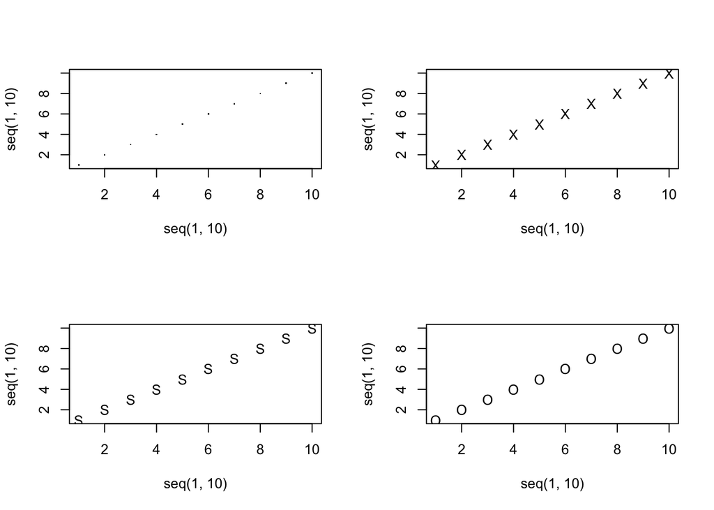

```r
par(mfrow=c(2,2))
plot(x=seq(1,10), y=seq(1,10), pch = ".")
plot(x=seq(1,10), y=seq(1,10), pch = "X")
plot(x=seq(1,10), y=seq(1,10), pch = "S")
plot(x=seq(1,10), y=seq(1,10), pch = "O")
```

### 숫자로 설정

특수한 점은 1에서 25사이의 숫자로 지정할 수 있음

(pch에 숫자로 설정하고 그 결과 확인) 다음은 25개의 서로 다른 점을 y=x 직선 위에 점으로 그려본 것이다.

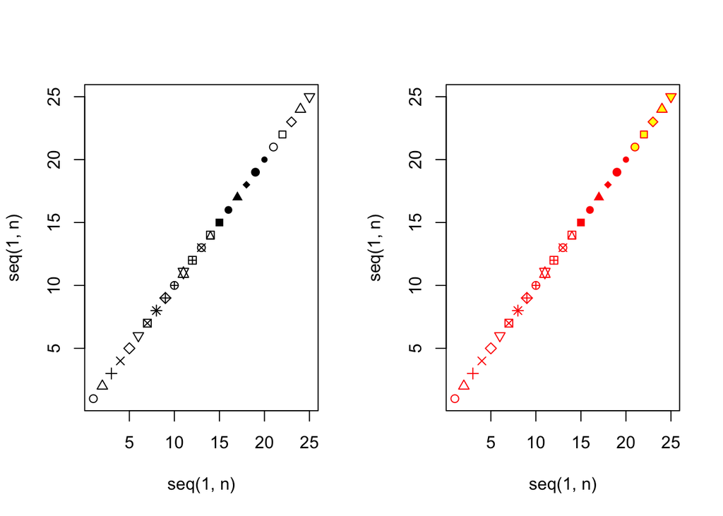

```r
n <- 25
par(mfrow = c(1,2))
plot(x=seq(1,n), y=seq(1,n), pch=seq(1,n))
plot(x=seq(1,n), y=seq(1,n), pch=seq(1,n), col = "red", bg = "yellow")
```

(산점도에서 그룹에 따라 다른 점으로 표시하기)  
* 키와 몸무게는 특성상 남자와 여자가 뚜렷하게 구분된다.  
* 따라서 BMI 자료로 키와 몸무게의 산점도를 그리되 성별에 따라 모양 및 색깔을 다르게 사용해보자

```r
BMI <- read.table("./bmi.txt",
                  col.names = c("height", "weight", "year", "religion", "gender", "marriage"))

head(BMI)
```

|  | height | weight | year | religion | gender | marriage |
| --- | --- | --- | --- | --- | --- | --- |
| 1 | 167 | 68 | 1974 | No | F | N |
| 2 | 162 | 49 | 1974 | C2 | F | N |
| 3 | 158 | 50 | 1978 | C2 | F | N |
| 4 | 165 | 56 | 1977 | No | F | N |
| 5 | 160 | 52 | 1959 | No | F | N |
| 6 | 162 | 52 | 1972 | No | F | Y |

```r
plot.test <- function() {
  # BMI data 읽어오기
  BMI <- read.table("./bmi.txt",
                  col.names = c("height", "weight", "year", "religion", "gender", "marriage"))

  # mypch와 mycol은 성별에 따른 점의 모양 및 색을 저장할 변수로
  # 길이는 BMI의 행의 갯수, 초깃값은 NULL
  mypch <- rep(NULL, dim(BMI)[1])
  mycol <- rep(NULL, dim(BMI)[1])

  # BMI의 gender가 female이면 mypch, mycol이 각각 "F" 및 "red",
  # gender가 male이면 mypch, mycol이 각각 "M" 및 "blue"로 설정
  mypch[BMI$gender == "F"] <- "F"
  mycol[BMI$gender == "F"] <- "red"
  mypch[BMI$gender == "M"] <- "M"
  mycol[BMI$gender == "M"] <- "blue"

  # 산점도를 그림
  plot(BMI$height, BMI$weight, type = "p", pch = mypch, col = mycol)
}
```

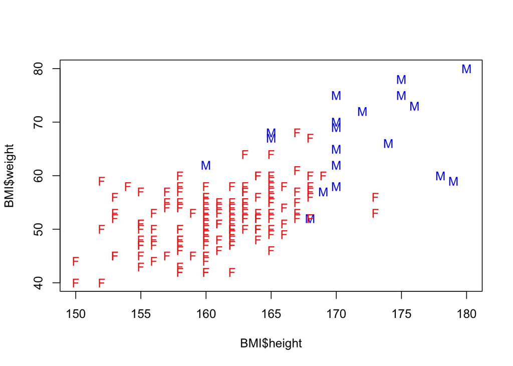

```r
plot.test()
```

## 선의 종류

### lty 옵션

- 산점도에서 선을 사용할 경우 사용할 선의 종류를 설정함
- 0에서 6까지의 숫자를 사용하거나 “blank”, “solid”, “dashed”, “dotted”, “dotdash”, “longdash”, “twodash” 중의 하나의 문자열을 사용함
- 숫자로 설정하는 경우 0=blank, 1=solid(기본값), 2=dashed, 3=dotted, 4=dotdash, 5=longdash, 6=twodash이며 문자열인 경우 이름이 의미하는 형태의 선을 그리게 됨
- blank 또는 0인 경우 선이 보이지 않음

### lty 옵션의 설정

(숫자에 따른 선의 형태) 한 평면에 함수 y=x, y=x+1, y=x+2, … ,y=x+6 (y=x를 y축으로 1씩 이동한 함수)를 그려 선의 종류를 확인해보자.

```r
line.types2 <- function() {
  x <- seq(1,10)
  y0 <- x
  y1 <- x+1
  y2 <- x+2
  y3 <- x+3
  y4 <- x+4
  y5 <- x+5
  y6 <- x+6

  matplot(x, cbind(y0, y1, y2, y3, y4, y5, y6), lty = 0:6, type = "l")
}
```

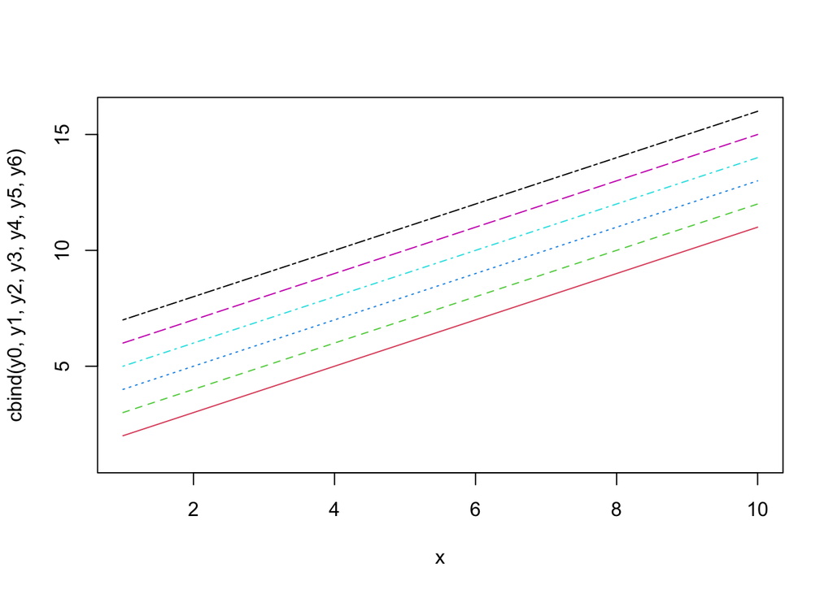

```r
line.types2()
```

## 선의 굵기

### lwd 옵션

- wd에 설정할 수 있는 값
  - 자연수이며 자연수로 설정된 값이 선의 굵기로 사용됨.
  - 단위는 픽셀이며, 자연수가 아닌 경우 1로 간주됨 (1픽셀 굵기의 선)

### lwd 옵션의 설정

```r
df <- readxl::read_xlsx("./grdp.xlsx", skip = 1)
head(df)
```

| ...1 | 2006 | 2007 | 2008 | 2009 | 2010 | 2011 | 2012 | 2013 | 2014 |
| --- | --- | --- | --- | --- | --- | --- | --- | --- | --- |
| 전국 | 966660 | 1043255 | 1105722 | 1151367 | 1265146 | 1330888 | 1377041 | 1430255 | 1484542 |
| 서울 | 231224 | 249485 | 263000 | 273199 | 289719 | 303813 | 313479 | 318607 | 327602 |
| 부산 | 52358 | 56193 | 60467 | 60695 | 63737 | 66648 | 67999 | 70338 | 73744 |
| 대구 | 32276 | 34388 | 35465 | 36017 | 38580 | 41448 | 43021 | 44754 | 46592 |
| 인천 | 47055 | 51638 | 51274 | 53796 | 60708 | 61854 | 62208 | 64654 | 68374 |
| 광주 | 20614 | 22310 | 22940 | 23834 | 26401 | 27789 | 28914 | 29763 | 30998 |

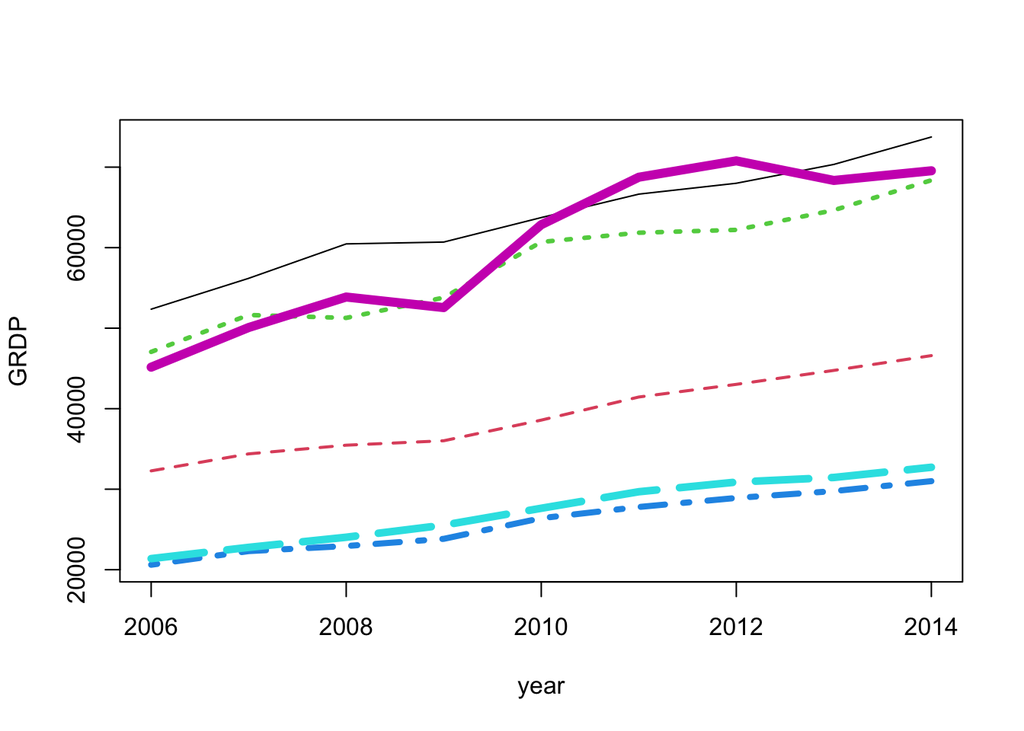

```r
matplot(seq(2006, 2014), t(df[3:8, -1]), type = "l", xlab = "year", ylab = "GRDP", lwd = seq(1,6))
```

- `matplot()`함수는 두 개이상에 대한 함수를 그리므로 따로 설정하지 않아도 색은 1번(검정)부터, 선의 형태는 1번 부터 시작하여 자동으로 바꿈

(선의 굵기를 음수로 설정한 경우) lwd = 1로 설정한 것과 같은 효과

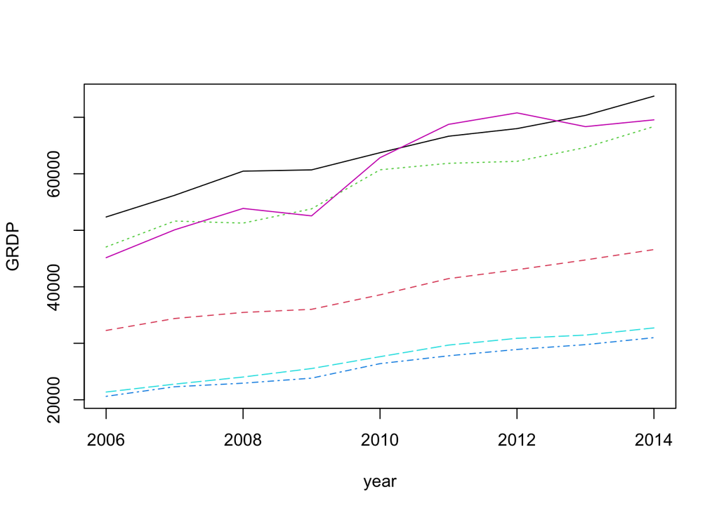

```r
matplot(seq(2006, 2014), t(df[3:8, -1]), type = "l", xlab = "year", ylab = "GRDP", lwd = seq(-6, -1))
```